# TP : Arbres de décision

Prédiction des performances académiques d'un étudiant et interprétation

*Objectifs* :

```
- Mettre en oeuvre les méthodes relatives aux arbres de décision introduites en cours afin de prédire le
résultat à un examen final du cursus de licence.
- Interpréter ces résultats pour discuter de l'équité du système éducatif considéré.
```

Dans cette séance, les librairies suivantes seront utilisées : installez-les si nécessaire et chargez-les. Il sera utile de consulter l'aide de R pour comprendre à quoi correspondent les paramètres et les attributs d'une fonction donnée.

```r
library('rpart')
library('rpart.plot')
library('randomForest')
library('gbm')
library('nnet')
```

## Table des matières

1 - Jeu de données : présentation et analyse

2 - Arbre de décision

2.1 - Construction de l'arbre

2.2 - Elagage

2.3 - Exploitation des résultats

3 - Amélioration de la prédiction

3.1 - Bagging (Bootstrap AGGregatING)

3.2 - Forêts aléatoires

3.3 - Boosting

4 - Comparison

5 - Interprétation

Références

## Jeu de données : présentation et analyse

Cette séance est inspirée des articles (Hussain et al., 2018) et (McDaniel, 2018) et le jeu de données original est disponible sur [UCI Machine Learning Repository](https://archive.ics.uci.edu/ml/datasets/Student+Academics+Performance). Le jeu de données étudié durant cette séance contient $300$ observations de $21$ prédicteurs présentés dans le tableau ci-dessous. Il s'agit de données concernant des étudiants indiens en fin de troisième année de licence (pour faciliter l'interprétation, nous transposons le système d'éducation indien en un équivalent français, avec les inexactitudes que cela peut induire).

| Nom | Description | Valeurs |
| --- | --- | --- |
| GE | Gender | Male (M)/ Female (F) |
| CST | Caste | General/SC/ST/OBC/MOBC |
| TNP | Class X Percentage | $[0,1]$ |
| TWP | Class XII Percentage | $[0,1]$ |
| IAP | Internal Assess Percentage | $[0,1]$ |
| ARR | Previous failed test | Yes (Y)/No (N) |
| MS | Marital Status | Married / Unmarried |
| LS | Live in Town or Village | Town (T)/Village (V) |
| AS | Admission Category | Free/Paid |
| FMI | Family Monthly Income (in Rupee) | $[0,+\infty[$ |
| FS | Family Size | $\mathbb{N}$ |
| FQ | Father Qualification | Illiterate (Il)/Under Class X (UM)/10/12/Degree/PG |
| MQ | Mother Qualification | Illiterate (Il)/Under Class X (UM)/10/12/Degree/PG |
| FO | Father Occupation | Service/Business/Retired/Farmer/Other |
| MO | Mother Occupation | Service/Business/Retired/Housewife/Other |
| NF | Number of Friends | $\mathbb{N}$ |
| SH | Study Hours | $[0,6]$ (h) |
| SS | Student School Attended at Class X level | Govt./Private |
| ME | Medium | English(Eng.)/Assamese(Asm.)/Hindi(Hin.)/Bengali(Ben.) |
| TT | Home to College Travel Time | $[0,2]$ (h) |
| ATD | Class Attendance Percentage | $[0,1]$ |

Détails :

- `CST` : 'General' désigne les castes qui ne sont pas discriminées. Les $4$ autres désignations (SC:Schelule Caste; ST:Schedule Tribe; OBC:Other Backward Class; MOBC:Minorities and Other Backward Class) recouvrent des classes sociales souvent victimes de discrimination. Par exemple, 'SC' inclut les Dalits, aussi appelés intouchables.
- `TNP` et `TWP` : le 'class X exam' est un certificat général de fin d’études secondaires dans le système scolaire indien; pour simplifier, on pourra considérer qu'il est équivalent au brevet des collèges en France. Le 'class XII exam' est un certificat général de fin d’études secondaires supérieures, on pourra considérer qu'il est équivalent au baccalauréat en France. La valeur associée, renormalisée, désigne le pourcentage de bonnes réponse à ces examens. Voir [ici](https://en.wikipedia.org/wiki/Higher_Secondary_School_Certificate) pour plus de détails.
- `IAP` : on pourra considérer cette variable comme la note de contrôle continu obtenue durant la licence.
- `ARR` : 'Yes' signifie que l'étudiant doit passer des rattrapages.
- `FQ` : '10' (resp. 12) désigne la validation de l'examen de class X (resp. XII); 'Degree' un niveau licence ou équivalent et 'PG'un niveau master ou plus.
- `ME` : le médium est la langue utilisée pour l'instruction et les examens.

La variable à prédire, ou réponse, notée `ESP` est le 'End Semester Percentage' qui est le résultat obtenu à l'examen final pour l'obtention du diplôme de licence. `ESP` prend $2$ valeurs :

- 'Pass' lorsque l'étudiant obtient un score de plus de 50%
- 'Fail' lorsque l'étudiant obtient un score de moins de 50%

Les données sont directement séparées en Train.csv pour l'apprentissage et Test.csv pour la validation.

> Tâche 1 : Importer et visualiser les données : y a-t-il des données manquantes ? aberrantes ? inutiles ? Quelle est la taille de l'ensemble d'apprentissage ? de l'ensemble de test ? Est-ce que cela est cohérent ? Quelles sont les données :
> - quantitatives ?
> - qualitatives ordonnées ?
> - qualitatives non-ordonnées ?

> La tâche de prédiction relève-t-elle de la régression ou de la classification ?

```r
#Charger les données
Train=read.csv('Train.csv')
Test=read.csv('Test.csv')
#On visualise les données avec summary par exemple.
summary(Train)
summary(Test)
#Données manquantes
sum(is.na(Train))
sum(is.na(Test))
```

```
 GE        CST          TNP              TWP            IAP         ARR
 F:114   G   :55   Min.   :0.3000   Min.   :0.31   Min.   :0.3100   N:110
 M:111   MOBC:40   1st Qu.:0.4400   1st Qu.:0.47   1st Qu.:0.5100   Y:115
         OBC :91   Median :0.5200   Median :0.54   Median :0.5700
         SC  :11   Mean   :0.5271   Mean   :0.55   Mean   :0.5894
         ST  :28   3rd Qu.:0.5900   3rd Qu.:0.61   3rd Qu.:0.6700
                   Max.   :0.9600   Max.   :0.95   Max.   :1.0000
         MS      LS         AS           FMI              FS
 Married  :  1   T: 48   Free:142   Min.   : 2552   Min.   : 1.000
 Unmarried:224   V:177   Paid: 83   1st Qu.: 4517   1st Qu.: 2.000
                                    Median : 7481   Median : 4.000
                                    Mean   :10360   Mean   : 5.004
                                    3rd Qu.:12097   3rd Qu.: 7.000
                                    Max.   :70593   Max.   :18.000
      FQ           MQ             FO             MO            NF
 10    : 35   10    : 36   Business:46   Housewife:202   Min.   : 1.000
 12    : 28   12    : 19   Farmer  :85   Others   :  4   1st Qu.: 5.000
 Degree: 17   Degree:  5   Others  :34   Service  : 19   Median : 8.000
 Il    : 38   Il    : 63   Retired : 2                   Mean   : 9.022
 Pg    :  5   Pg    :  2   Service :58                   3rd Qu.:12.000
 Um    :102   Um    :100                                 Max.   :20.000
       SH              SS        ME            TT              ATD
 Min.   :0.000   Govt   :166   Asm:145   Min.   :0.0000   Min.   :0.1100
 1st Qu.:1.500   Private: 59   Ben:  2   1st Qu.:0.2500   1st Qu.:0.6000
 Median :2.500                 Eng: 76   Median :0.5000   Median :0.7200
 Mean   :2.651                 Hin:  2   Mean   :0.5644   Mean   :0.6699
 3rd Qu.:3.500                           3rd Qu.:0.7500   3rd Qu.:0.8300
 Max.   :6.000                           Max.   :2.0000   Max.   :1.0000
   ESP
 Fail: 77
 Pass:148
```

```
 GE       CST          TNP              TWP              IAP         ARR
 F:36   G   :21   Min.   :0.3000   Min.   :0.3000   Min.   :0.3000   N:38
 M:39   MOBC:14   1st Qu.:0.4400   1st Qu.:0.4950   1st Qu.:0.4950   Y:37
        OBC :27   Median :0.5200   Median :0.5500   Median :0.5500
        SC  : 2   Mean   :0.5345   Mean   :0.5631   Mean   :0.5827
        ST  :11   3rd Qu.:0.5950   3rd Qu.:0.6250   3rd Qu.:0.6650
                  Max.   :1.0000   Max.   :0.9200   Max.   :0.9600
         MS     LS        AS          FMI              FS              FQ
 Unmarried:75   T:12   Free:49   Min.   : 2780   Min.   : 1.000   10    : 8
                V:63   Paid:26   1st Qu.: 5046   1st Qu.: 3.000   12    :10
                                 Median : 8330   Median : 4.000   Degree: 9
                                 Mean   :11651   Mean   : 4.667   Il    :12
                                 3rd Qu.:11510   3rd Qu.: 6.000   Pg    : 3
                                 Max.   :80292   Max.   :11.000   Um    :33
      MQ            FO             MO           NF               SH
 10    :12   Business:16   Housewife:67   Min.   : 1.000   Min.   :0.00
 12    : 7   Farmer  :32   Others   : 3   1st Qu.: 4.500   1st Qu.:2.00
 Degree: 3   Others  : 7   Service  : 5   Median : 9.000   Median :3.00
 Il    :13   Retired : 2                  Mean   : 9.533   Mean   :2.84
 Pg    : 2   Service :18                  3rd Qu.:15.000   3rd Qu.:3.50
 Um    :38                                Max.   :20.000   Max.   :6.00
       SS       ME           TT            ATD           ESP
 Govt   :55   Asm:48   Min.   :0.00   Min.   :0.1100   Fail:31
 Private:20   Eng:22   1st Qu.:0.00   1st Qu.:0.5100   Pass:44
              Hin: 5   Median :0.50   Median :0.6800
                       Mean   :0.58   Mean   :0.6461
                       3rd Qu.:1.00   3rd Qu.:0.8250
                       Max.   :2.00   Max.   :1.0000
```

0

0

> Réponse : Pas de donnée manquante ni aberrante. La variable explicative `MS` n'est pas pertinente car elle ne prend la valeur 'married' qu'une seule fois. De même, les classes des variables `MO`, `FO`, `MQ`, `FQ`et `ME`ne sont pas équilibrées. Train : 225 observations et Test : 75 observation : 75% des données sont dévolues à l'apprentissage et 25% au test : c'est classique. Variables quantitatives : `TNP`, `TWP`, `IAP`,`FMI`,`FS`,`NF`, `SH`, `TT`, `ATD`. Variables qualitatives ordonnées : `ESP`, `FQ`,`MQ`. Variables qualitatives non-ordonnées : `GE`, `CST`, `ARR`,`MS`, `LS`, `AS`,`FO`,`MO`, `SS`, `ME`. C'est un travail de classification.

## Arbre de décision

### Construction de l'arbre

> Tâche 2 : Sur l'ensemble d'apprentissage, déterminer l’arbre de décision permettant de prédire la catégorie à partir des variables explicatives en utilisant la fonction `rpart` avec les paramètres par défault (voir [ici](https://stat.ethz.ch/R-manual/R-patched/library/rpart/html/rpart.html)) :
> - quel critère est minimisé lors d'une coupe ?
> - combien y a-t-il au minimum d'observations dans chaque feuille ?
> - à quoi correspond le paramètre `cp` dans `rpart.control`?

> Afficher l'arbre à l'aide de la fonction `rpart.plot`. On considère le nœud terminal (la feuille) $n^o 3$ :
> - Quelle est la prédiction effectuée ?
> - Avec quelle probabilité ?
> - Sur combien d’observations ?

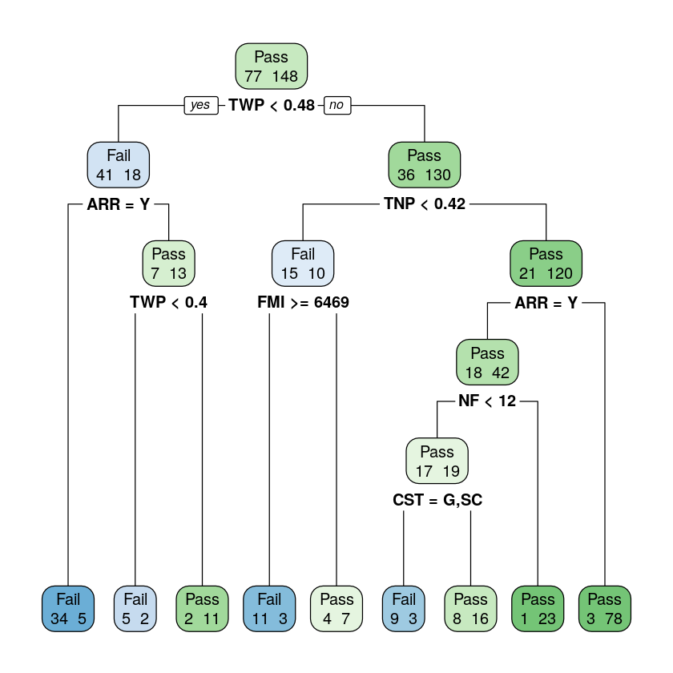

```r
X_train=Train[,-22]
y_train=Train[,22]
X_test=Test[,-22]
y_test=Test[,22]

fit <- rpart(y_train~ .,data=X_train)
rpart.plot(fit,extra=1)
```

> Réponse : L'indice de Gini est minimisé par défaut (paramètre `parms`). Il y au moins $\lceil 20/3\rceil$ observations par feuille (paramètre `minbucket` dans `rpart.control`. Une coupe qui n'améliore pas l'indice d'un facteur au moins `cp` n'est pas envisagée.

> La prédiction pour la feuille $n^o 3$ est 'Pass', avec probabilité $84$%. Elle est effectuée sur $13$ observations, soit $5.8$% des observations.

En classification, on rappelle que la qualité du modèle est mesurée via la précision : $$precision(y,\hat{y})=\frac{1}{n}\sum_{i=1}^n 1_{y_i=\hat{y}_i}$$ où $n$ est la taille de l'ensemble de test, $\hat{y}_{i}$ la valeur prédite du $i^{ème}$ individu et $y_i$ sa vraie valeur. Le taux d'erreur est donné par $1-precision(y,\hat{y})$.

> Tâche 3 : Evaluer la qualité du modèle sur les ensembles d'entraînement et de test. Afficher la matrice de confusion et le taux d'erreur de classification pour chacun des ensembles.

```r
confMat<-table(predict(fit, X_train, type = "class"), y_train)
precision<-sum(diag(confMat))/sum(confMat)
print(confMat)
print(1-precision)

confMat<-table(predict(fit, X_test, type = "class"), y_test)
precision<-sum(diag(confMat))/sum(confMat)
print(confMat)
print(1-precision)
```

```
      y_train
       Fail Pass
  Fail   59   13
  Pass   18  135
[1] 0.1377778
      y_test
       Fail Pass
  Fail   14    6
  Pass   17   38
[1] 0.3066667
```

> Tâche 4 (optionelle): Sur l'ensemble d'apprentissage, pour les deux critères (indice de Gini et entropie), construire un arbre maximal avec (idéalement) une observation par feuille, un arbre avec au plus $m=10$ observations par feuilles et au plus $m=20$ observations par feuilles. Calculer le taux d'erreur pour chaque cas. Empiriquement, pour ce jeu de données, quel critère de coupe est préférable ?

```r
precision_gini<-c()
for (i in c(11,21)){
    fit <- rpart(y_train~ .,data=X_train,control = rpart.control(cp=0,minsplit=i))
    confMat<-table(predict(fit, X_test, type = "class"), y_test)
    precision<-sum(diag(confMat))/sum(confMat)
    precision_gini<-c(precision_gini,1-precision)
}

precision_entropie<-c()
for (i in c(11,21)){
    fit <- rpart(y_train~ .,data=X_train,parms=list(split = "information"),control = rpart.control(cp=0,minsplit=i))
    confMat<-table(predict(fit, X_test, type = "class"), y_test)
    precision<-sum(diag(confMat))/sum(confMat)
    precision_entropie<-c(precision_entropie,1-precision)
}

#arbre max entropie
fit <- rpart(y_train~ .,data=X_train,parms=list(split = "information"),control = rpart.control(cp=-1,minsplit=2,minbucket=1))
confMat<-table(predict(fit, X_test, type = "class"), y_test)
precision_max_e<-1-sum(diag(confMat))/sum(confMat)

#arbre max gini
fit <- rpart(y_train~ .,data=X_train,control = rpart.control(cp=-1,minsplit=2,minbucket=1))
confMat<-table(predict(fit, X_test, type = "class"), y_test)
precision_max_g<-1-sum(diag(confMat))/sum(confMat)

#arbre par défaut, entropie
fit <- rpart(y_train~ .,data=X_train,parms=list(split = "information"))
confMat<-table(predict(fit, X_test, type = "class"), y_test)
precision_defaut_e<-1-sum(diag(confMat))/sum(confMat)

print(precision_gini)
print(precision_max_g)
print(precision_entropie)
print(precision_max_e)
print(precision_defaut_e)
```

```
[1] 0.2533333 0.3200000
[1] 0.24
[1] 0.2800000 0.2666667
[1] 0.2533333
[1] 0.2666667
```

### Elagage

La qualité de prédiction de l'arbre varie avec le nombre d'observations par feuille.

Nous allons dans cette partie chercher de manière plus systématique le meilleur sous-arbre en terme de prédiction.

Pour ce faire, nous appliquons la méthode vue en cours, qui consiste, à partir de l'arbre maximal (voir aussi [ici](http://mlwiki.org/index.php/Cost-Complexity_Pruning)):

1. Sélectionner une suite de sous-arbres emboîtés et la pénalité $\alpha$ correspondante via la méthode de *cost complexity pruning*.
2. Sélectionner le 'meilleur' sous-arbre en effectuant une validation croisée sur les pénalités $\alpha$.

> Tâche 5 : la méthode `rpart` de R effectue déjà directement les deux points ci-dessus. Les valeurs sont stockées dans l'attribut `cptable` de l'objet arbre fourni. Pour visualiser ces $\alpha$ et l'erreur correspondante en validation croisée, utiliser la fonction `plotcp`. Donner la valeur $\alpha$ correspondant au meilleur sous-arbre.

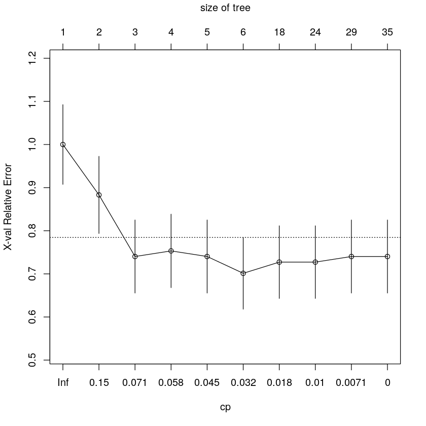

```r
fit.max <- rpart(y_train~ .,data=X_train,control = rpart.control(cp=0, minsplit = 2,minbucket =1))
plotcp(fit.max)
```

```r
printcp(fit.max)
```

```
Classification tree:
rpart(formula = y_train ~ ., data = X_train, control = rpart.control(cp = 0,
    minsplit = 2, minbucket = 1))

Variables actually used in tree construction:
 [1] ARR ATD CST FMI FO  FQ  GE  IAP ME  MQ  NF  SH  TNP TWP

Root node error: 77/225 = 0.34222

n= 225

          CP nsplit rel error  xerror     xstd
1  0.2987013      0  1.000000 1.00000 0.092426
2  0.0779221      1  0.701299 0.88312 0.089459
3  0.0649351      2  0.623377 0.74026 0.084725
4  0.0519481      3  0.558442 0.75325 0.085210
5  0.0389610      4  0.506494 0.74026 0.084725
6  0.0259740      5  0.467532 0.70130 0.083198
7  0.0129870     17  0.155844 0.72727 0.084228
8  0.0077922     23  0.077922 0.72727 0.084228
9  0.0064935     28  0.038961 0.74026 0.084725
10 0.0000000     34  0.000000 0.74026 0.084725
```

```r
fit.max$cptable
```

A matrix: 10 × 5 of type dbl

|  | CP | nsplit | rel error | xerror | xstd |
| --- | --- | --- | --- | --- | --- |
| 1 | 0.298701299 | 0 | 1.00000000 | 1.0000000 | 0.09242602 |
| 2 | 0.077922078 | 1 | 0.70129870 | 0.8831169 | 0.08945864 |
| 3 | 0.064935065 | 2 | 0.62337662 | 0.7402597 | 0.08472471 |
| 4 | 0.051948052 | 3 | 0.55844156 | 0.7532468 | 0.08520994 |
| 5 | 0.038961039 | 4 | 0.50649351 | 0.7402597 | 0.08472471 |
| 6 | 0.025974026 | 5 | 0.46753247 | 0.7012987 | 0.08319801 |
| 7 | 0.012987013 | 17 | 0.15584416 | 0.7272727 | 0.08422779 |
| 8 | 0.007792208 | 23 | 0.07792208 | 0.7272727 | 0.08422779 |
| 9 | 0.006493506 | 28 | 0.03896104 | 0.7402597 | 0.08472471 |
| 10 | 0.000000000 | 34 | 0.00000000 | 0.7402597 | 0.08472471 |

> Réponse : On prend $\alpha=0.0259$

### Exploitation des résultats

> Tâche 6 : L'élagage a permi de sélectionner le meilleur sous-arbre. Construire cet arbre à l'aide de la fonction `prune`. Quel est le taux d'erreur de classification de cet arbre sur l'ensemble de test ? Afficher la matrice de confusion. Quel est le nombre de mal classés par l’arbre dans l’échantillon ? Visualiser cet arbre. Quelles sont les trois variables les plus importantes pour la détermination de la catégorie ?

> On considère une nouvelle observation (F,OBS,0.38,0.45,0.49,Y,Unmarried,V,Paid,5720,1,10,Um,Others,Housewife,20, 3,Govt,Asm,1,0.78) : prédire le résultat de cet étudiant à l'examen.

```
[1] 0.2533333
      y_test
       Fail Pass
  Fail   18    6
  Pass   13   38
```

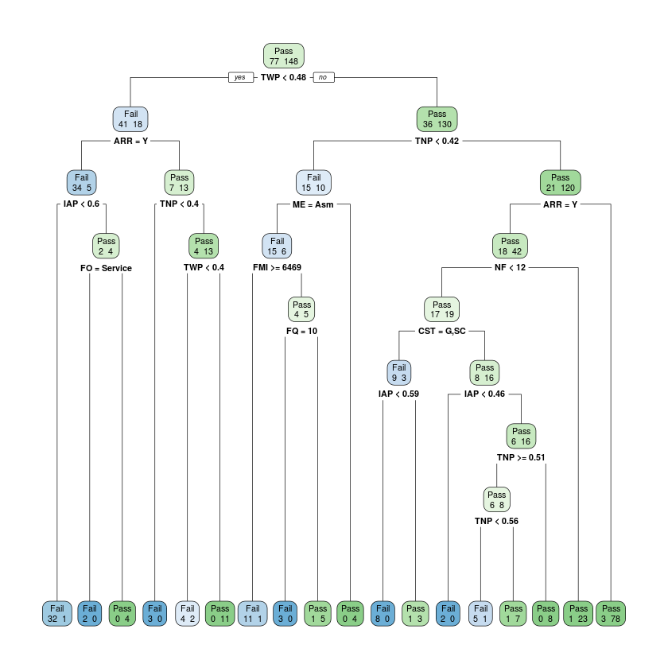

```r
tree<-prune(fit.max,cp=0.0259)
rpart.plot(tree,extra=1)
confMat<-table(predict(tree, X_test, type = "class"), y_test)
precision<-sum(diag(confMat))/sum(confMat)
print(1-precision)
print(confMat)
```

> Réponse : Taux d'erreurs : $25.3$%. Nombre de mal classés : $19$. Variables importantes : TWP, ARR et TNP. Nouvelle prédiction : 'Fail'.

> Tâche 7 (facultatif) : Observer comment les résultats précédents sont impactés (en particulier dans les tâches 6 et 7) si l'on change les échantillons d'entraînement et de test. Comment expliquer ces résultats ?

```
[1] 0.2666667
      y_test2
       Fail Pass
  Fail   15   16
  Pass    4   40
```

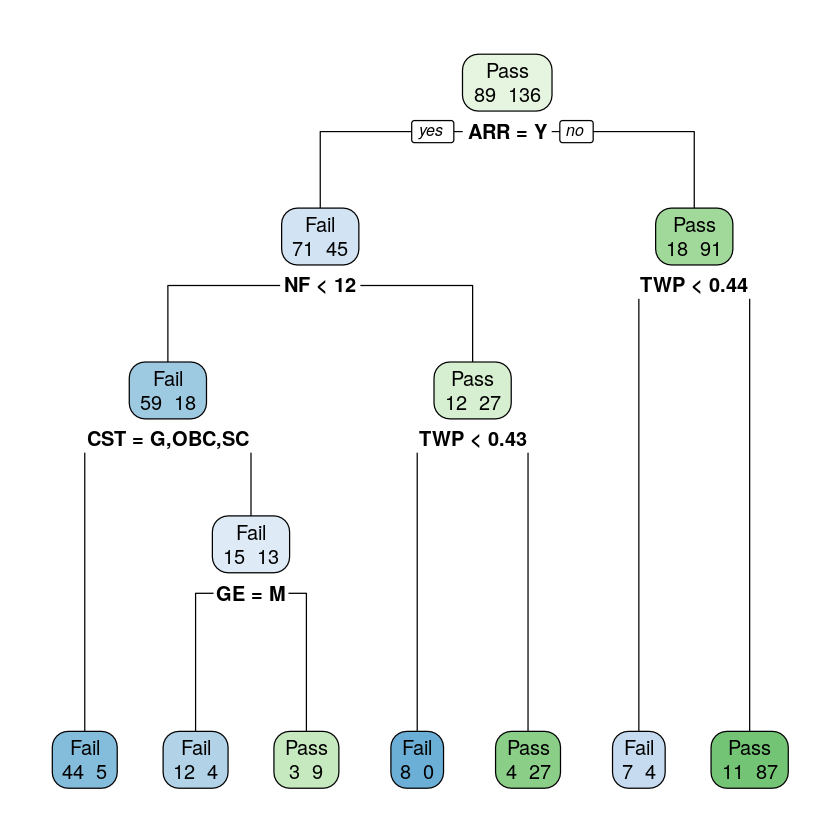

```r
Train2<-Train
Train2[(151:225),]<-Test
Test2<-Train[(151:225),]

X_train2=Train2[,-22]
y_train2=Train2[,22]
X_test2=Test2[,-22]
y_test2=Test2[,22]

fit <- rpart(y_train2~ .,data=X_train2)
rpart.plot(fit,extra=1)

confMat<-table(predict(fit, X_test2, type = "class"), y_test2)
precision<-sum(diag(confMat))/sum(confMat)
print(1-precision)
print(confMat)
```

> Réponse : On obtient des arbres et des résultats très différents. On a vu en cours que la méthode des arbres de décision présente une grande variance. En particulier, elle est très sensible à l'échantillon utilisé pour l'entraînement.

## Amélioration de la prédiction

Nous allons maintenant mettre en place les méthodes de réduction de la variance introduites en cours afin d'améliorer la prédiction.

### Bagging (Bootstrap AGGregatING)

> Tâche 8 : Rappeler quelle est la différence entre Bagging et Forêt aléatoire. Effectuer une prédiction en utilisant la méthode de Bagging (fonction `randomForest` se trouvant dans la librairie du même nom). Tracer le taux d'erreur sur l'ensemble de test en fonction du nombre d'arbres utilisés. Tracer sur le même graphe le taux d'erreur 'out-of-bag'.

```
 [1] 0.2133333 0.2133333 0.2133333 0.2266667 0.2000000 0.2133333 0.2133333
 [8] 0.2400000 0.2266667 0.2000000 0.2000000 0.2133333
```

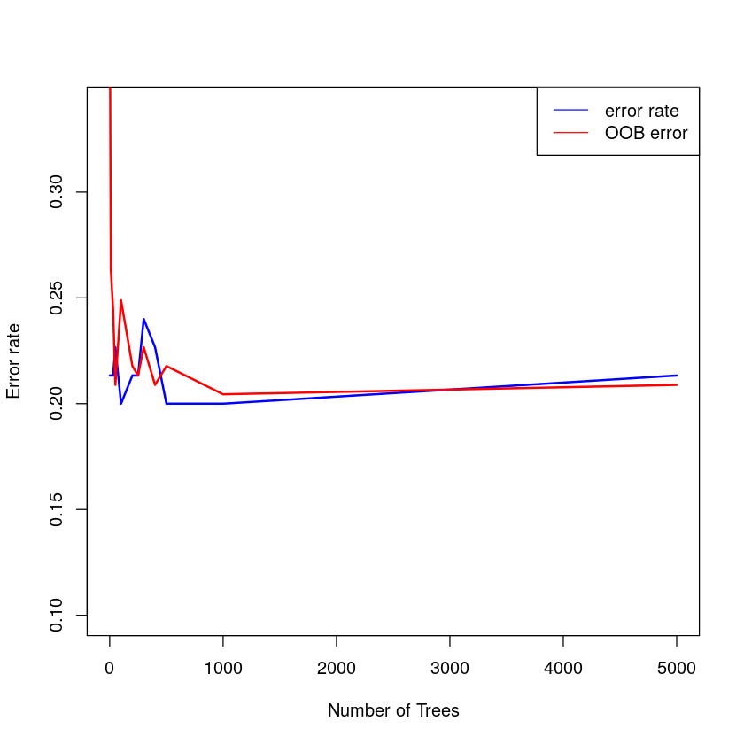

```r
error_rate<-c()
error_rate_oo<-c()
p=21
Ntrees=c(1,10,30,50,100,200,250,300,400,500,1000,5000)
for(i in Ntrees){
    fit.rf <- randomForest(y_train ~ ., data=X_train,xtest=X_test,ytest=y_test,ntree=i ,mtry=p, importance=TRUE)
    cm<-fit.rf$confusion
    error_rate_oo<-c(error_rate_oo,1-sum(diag(cm))/sum(cm[,-3]))
    confMat<-fit.rf$test$confusion
    error_rate<-c(error_rate,1-sum(diag(confMat))/sum(confMat[,-3]))
}
print(error_rate)
plot(Ntrees,error_rate,type='l',col='blue',lwd=2,ylim=c(min(error_rate)-0.1,max(error_rate)+0.1),ylab="Error rate",xlab="Number of Trees")
points(Ntrees,error_rate_oo,type='l',col='red',lwd=2)
legend("topright", legend=c("error rate","OOB error"),lty = c(1,1),col=c("blue","red"))
```

> Tâche 9 : Déterminer quelles sont les variables les plus importantes en utilisant l'attribut `importance` et/ou la fonction `varImpPlot`.

A matrix: 21 × 4 of type dbl

|  | Fail | Pass | MeanDecreaseAccuracy | MeanDecreaseGini |
| --- | --- | --- | --- | --- |
| GE | -5.641995e-05 | -0.0003533201 | -0.0002467894 | 0.1989215 |
| CST | -6.768224e-04 | 0.0011977299 | 0.0005277870 | 3.7733751 |
| TNP | 5.622335e-02 | 0.0319660414 | 0.0399230578 | 14.9953006 |
| TWP | 6.641214e-02 | 0.0341706827 | 0.0449473774 | 20.3376428 |
| IAP | 5.987112e-02 | 0.0090194530 | 0.0261008339 | 12.4772417 |
| ARR | 6.454759e-02 | 0.0306537307 | 0.0418808414 | 12.8265026 |
| MS | 0.000000e+00 | 0.0000000000 | 0.0000000000 | 0.2376056 |
| LS | -3.562040e-04 | -0.0003867509 | -0.0003772089 | 0.1559198 |
| AS | 2.061223e-03 | 0.0018066281 | 0.0018894610 | 0.7464465 |
| FMI | -3.940791e-04 | 0.0042144190 | 0.0026954891 | 5.7100469 |
| FS | -2.883065e-03 | -0.0022115906 | -0.0024388514 | 2.3976167 |
| FQ | 2.078438e-03 | 0.0005525291 | 0.0010548153 | 2.5686211 |
| MQ | 1.877131e-03 | -0.0002477795 | 0.0004806343 | 1.9468014 |
| FO | 2.023887e-04 | -0.0017417091 | -0.0010645050 | 1.6150040 |
| MO | 1.497972e-04 | -0.0003929706 | -0.0002161144 | 0.3622432 |
| NF | 1.213060e-02 | 0.0054066131 | 0.0077016978 | 6.4078970 |
| SH | 6.227598e-03 | -0.0084513341 | -0.0034839813 | 3.3253681 |
| SS | 1.507821e-04 | 0.0010151048 | 0.0007126527 | 0.4822996 |
| ME | 3.198538e-03 | -0.0007393785 | 0.0005947336 | 0.6645274 |
| TT | -3.610006e-04 | -0.0005632028 | -0.0004511458 | 2.1895113 |
| ATD | 1.802986e-03 | 0.0038552398 | 0.0031508329 | 7.4759514 |

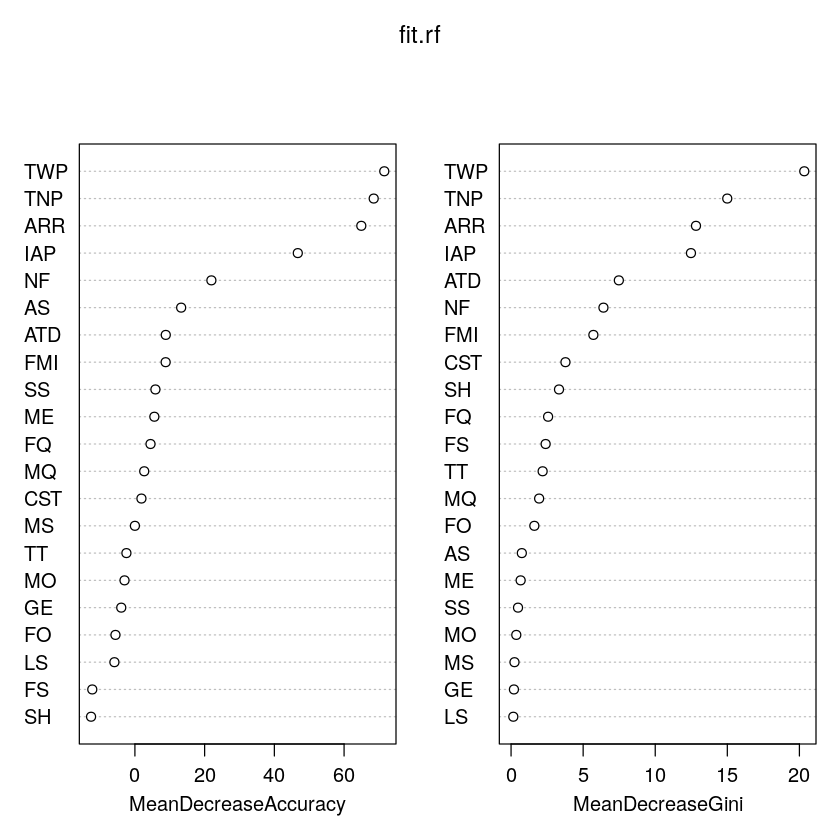

```r
fit.rf<-randomForest(y_train ~ ., data=X_train,xtest=X_test,ytest=y_test,ntree=5000 ,mtry=p, importance=TRUE)
fit.rf$importance
varImpPlot(fit.rf)
```

### Forêts aléatoires

> Tâche 10 : Effectuer une prédiction en utilisant les forêts aléatoires. Pour différents nombres de variables explicatives échantillonnées $m=\sqrt{p}$, $m=p/2$ où $p$ est le nombre total de variables explicatives ($p=21$), tracer le taux d'erreur sur l'ensemble de test en fonction du nombre d'arbres utilisés. Tracer sur le même graphe le taux d'erreur 'out-of-bag'

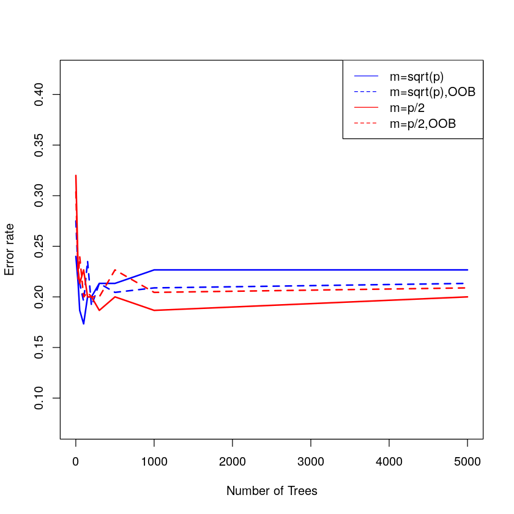

```r
error_rate<-c()
error_rate_oo<-c()
p=21
Ntrees=c(1,30,50,100,150,200,300,500,1000,5000)
for( m in c(sqrt(p),p/2)){
    for(i in Ntrees){
        fit.rf <- randomForest(y_train ~ ., data=X_train,xtest=X_test,ytest=y_test,ntree=i ,mtry=m,maxnodes=30, importance=TRUE)
        cm<-fit.rf$confusion
        error_rate_oo<-c(error_rate_oo,1-sum(diag(cm))/sum(cm[,-3]))
        confMat<-fit.rf$test$confusion
        error_rate<-c(error_rate,1-sum(diag(confMat))/sum(confMat[,-3]))
    }
}
l=length(Ntrees)
plot(Ntrees,error_rate[(1:l)],type='l',col='blue',lwd=2,ylim=c(min(error_rate)-0.1,max(error_rate)+0.1),ylab="Error rate",xlab="Number of Trees")
points(Ntrees,error_rate_oo[(1:l)],type='l',col='blue',lty=2,lwd=2)
points(Ntrees,error_rate[((1+l):(2*l))],type='l',col='red',lwd=2,ylab="Error rate",xlab="Number of Trees")
points(Ntrees,error_rate_oo[((1+l):(2*l))],type='l',col='red',lty=2,lwd=2)
legend("topright", legend=c("m=sqrt(p)","m=sqrt(p),OOB","m=p/2","m=p/2,OOB"),lty = c(1,2,1,2),col=c("blue","blue","red","red"))
```

> Tâche 11 : Déterminer quelles sont les variables les plus importantes en utilisant l'attribut `importance` et/ou la fonction `varImpPlot` pour la méthode de forêt aléatoire la plus performante.

```
 [1] 0.2400000 0.2133333 0.1866667 0.1733333 0.2000000 0.2000000 0.2133333
 [8] 0.2133333 0.2266667 0.2266667 0.3200000 0.2266667 0.2133333 0.2266667
[15] 0.2000000 0.2000000 0.1866667 0.2000000 0.1866667 0.2000000
```

A matrix: 21 × 4 of type dbl

|  | Fail | Pass | MeanDecreaseAccuracy | MeanDecreaseGini |
| --- | --- | --- | --- | --- |
| GE | -9.214463e-05 | -0.0007376429 | -0.0004983785 | 0.3572550 |
| CST | -8.373814e-04 | 0.0010423435 | 0.0005640607 | 3.6738618 |
| TNP | 5.162383e-02 | 0.0255411390 | 0.0341669128 | 15.0994312 |
| TWP | 6.655941e-02 | 0.0306300136 | 0.0428130310 | 18.6120168 |
| IAP | 6.172175e-02 | 0.0114085016 | 0.0284011917 | 13.0157229 |
| ARR | 6.511556e-02 | 0.0302406040 | 0.0419719822 | 11.9978549 |
| MS | 0.000000e+00 | 0.0000000000 | 0.0000000000 | 0.2095689 |
| LS | -2.566031e-04 | -0.0003700370 | -0.0003309274 | 0.2541781 |
| AS | 4.037090e-03 | 0.0016702408 | 0.0024797503 | 0.9633198 |
| FMI | 1.256507e-03 | 0.0023108410 | 0.0019318068 | 5.7007436 |
| FS | -3.398040e-03 | -0.0028844975 | -0.0030467242 | 2.6317633 |
| FQ | 3.536231e-03 | -0.0001281049 | 0.0011841037 | 3.1053636 |
| MQ | 9.165448e-04 | -0.0009382516 | -0.0002629218 | 1.8912642 |
| FO | 1.196003e-03 | -0.0017631254 | -0.0007350518 | 2.1436066 |
| MO | 1.008952e-04 | -0.0006164002 | -0.0003589970 | 0.4710678 |
| NF | 1.367166e-02 | 0.0042577032 | 0.0073841305 | 5.9774812 |
| SH | 6.334599e-03 | -0.0049140860 | -0.0010698166 | 3.2894417 |
| SS | -7.843474e-05 | 0.0010267584 | 0.0006299485 | 0.6363886 |
| ME | 2.941759e-03 | -0.0003674156 | 0.0007641522 | 0.8175720 |
| TT | -9.891975e-04 | -0.0011278373 | -0.0010295220 | 2.4513774 |
| ATD | 1.380142e-03 | 0.0036484067 | 0.0029808898 | 6.9321565 |

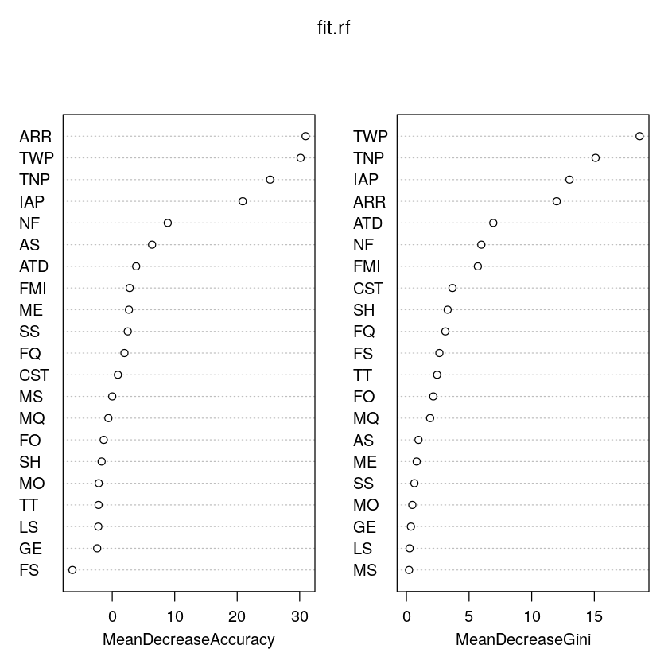

```r
print(error_rate)
fit.rf <- randomForest(y_train ~ ., data=X_train,xtest=X_test,ytest=y_test,ntree=1000 ,mtry=p/2,maxnodes=30, importance=TRUE)
fit.rf$importance
varImpPlot(fit.rf)
```

### Boosting

> Tâche 12 : En utilisant la méthode de boosting, via la fonction `gbm` du package du même nom, contruire une séquence de $5000$ arbres. Calculer le taux d'erreur sur l'ensemble de test. Tracer le taux d'erreur en fonction du nombre d'arbres.

```r
Train$ESP<-(Train$ESP=='Pass')
```

```
Distribution not specified, assuming bernoulli ...
Distribution not specified, assuming bernoulli ...
```

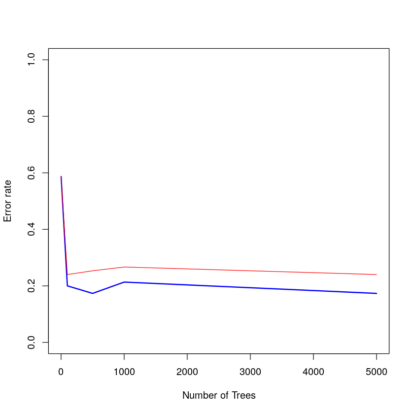

```r
error_rate3<-c()
error_rate1<-c()
fit3.boost<-gbm(ESP~.,data=Train,n.trees=5000,interaction.depth = 3)
fit1.boost<-gbm(ESP~.,data=Train,n.trees=5000,interaction.depth = 1)
for (i in c(1,100,500,1000,5000)){
    pred3.boost <- predict(fit3.boost, newdata = X_test, n.trees =i, type="response")
    labels = (pred3.boost>=0.5)
    cm = table(y_test, labels)
    error_rate3<-c(error_rate3,1-sum(diag(cm))/sum(cm))
}
for (i in c(1,100,500,1000,5000)){
    pred1.boost <- predict(fit1.boost, newdata = X_test, n.trees =i, type="response")
    labels = (pred1.boost>=0.5)
    cm = table(y_test, labels)
    error_rate1<-c(error_rate1,1-sum(diag(cm))/sum(cm))
}
plot(c(1,100,500,1000,5000),error_rate3,type='l',col='blue',lwd=2,ylim=c(0,1),ylab="Error rate",xlab="Number of Trees")
lines(c(1,100,500,1000,5000),error_rate1,type='l',col='red')
```

> Tâche 13 : Utiliser la fonction `summary` pour identifier les variables d'importance.

```
[1] 0.5866667 0.2000000 0.1733333 0.2133333 0.1733333
```

A data.frame: 21 × 2

|  | var <fct> | rel.inf <dbl> |
| --- | --- | --- |
| TWP | TWP | 17.52644735 |
| TNP | TNP | 14.40561946 |
| IAP | IAP | 12.96573737 |
| ARR | ARR | 12.77298816 |
| ATD | ATD | 7.31112910 |
| FMI | FMI | 6.36702536 |
| NF | NF | 5.94114508 |
| FQ | FQ | 4.41184510 |
| CST | CST | 3.72805817 |
| MQ | MQ | 3.25985060 |
| FO | FO | 2.66890934 |
| TT | TT | 2.53325844 |
| SH | SH | 2.47558187 |
| FS | FS | 2.33864687 |
| AS | AS | 0.47089162 |
| ME | ME | 0.28319999 |
| SS | SS | 0.26797094 |
| GE | GE | 0.20938852 |
| LS | LS | 0.03710380 |
| MO | MO | 0.02520284 |
| MS | MS | 0.00000000 |

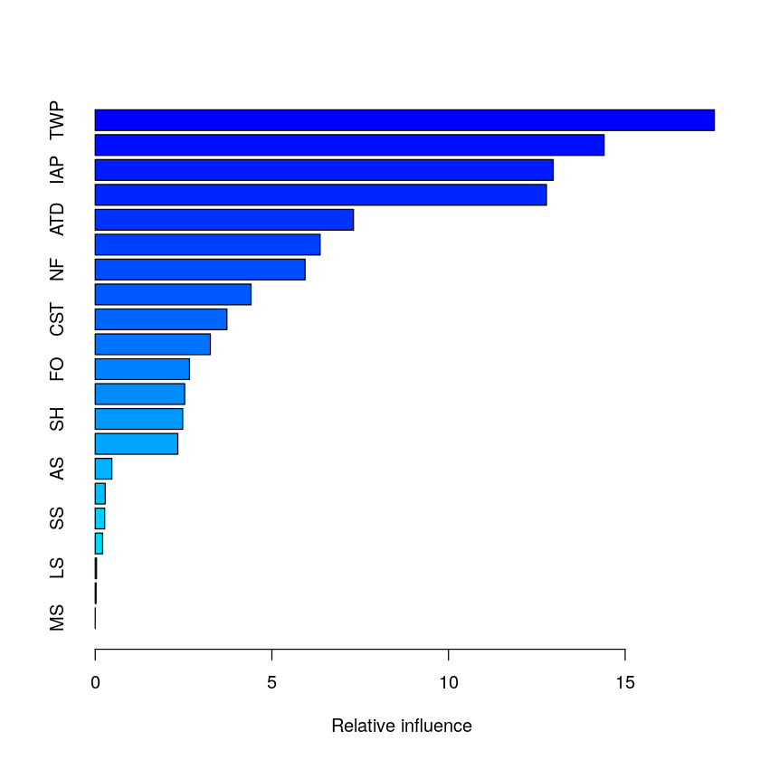

```r
print(error_rate3)
summary(fit3.boost, n.trees = 5000)
```

## Comparaison

Dans cette dernière partie, on applique une autre méthode de classification à notre jeu de données à titre de comparaison avec les méthodes par arbres en général. On se tourne vers une méthode qui est également adaptée, c'est-à-dire qui est capable de traiter des variables quantitatives et qualitatives non-ordonnées. On choisit la régression logistique multinomiale `multinom` fournie par la librairie `nnet` de R.

> Tâche 14 : Effectuer une régression logistique multinomiale sur le jeu de données et déterminer son taux d'erreur sur l'ensemble de test.

```r
fit.glm<-multinom(ESP~.,Train)
pred<-predict(fit.glm,X_test,type='class')
cm = table(y_test, pred)
error_rate<-1-sum(diag(cm))/sum(cm)
print(error_rate)
summary(fit.glm)
```

```
[1] 0.2133333
```

```
Call:
multinom(formula = ESP ~ ., data = Train)

Coefficients:
                   Values    Std. Err.
(Intercept) -1.750987e+02 1.883954e-02
GEM          2.287231e-01 1.054828e-02
CSTMOBC      9.272503e-01 4.597993e-03
CSTOBC       1.057380e+00 6.395380e-03
CSTSC        1.092455e+00 1.626194e-03
CSTST        1.512531e+00 2.257949e-03
TNP          8.576651e+00 8.283566e-03
TWP          7.744732e+00 9.713205e-03
IAP          8.405076e+00 1.170233e-02
ARRY        -2.695302e+00 1.585433e-02
MSUnmarried  1.617570e+02 1.883954e-02
LSV          1.734313e-01 1.960400e-02
ASPaid       4.916285e-01 1.418752e-03
FMI         -1.899105e-05 3.009895e-05
FS           9.120762e-02 6.494524e-02
FQ12         1.958665e+00 3.718318e-03
FQDegree     2.396967e+00 5.113485e-04
FQIl         6.560962e-01 2.904885e-03
FQPg        -8.154531e-01 5.987380e-05
FQUm         1.356272e-01 1.112195e-02
MQ12        -1.379345e+00 1.935796e-03
MQDegree     4.144674e+01 0.000000e+00
MQIl        -4.572316e-01 3.578931e-03
MQPg         6.676101e+00 4.286504e-09
MQUm        -1.103290e+00 9.436066e-03
FOFarmer    -1.076551e+00 1.332482e-02
FOOthers     6.235225e-01 2.194339e-03
FORetired    2.334901e+01 0.000000e+00
FOService   -1.192937e+00 2.598297e-03
MOOthers    -1.626558e+00 4.700440e-04
MOService    1.512975e-01 5.777817e-04
NF           7.003935e-02 3.810152e-02
SH           1.453451e-01 1.172072e-01
SSPrivate   -5.759957e-01 6.567138e-03
MEBen        2.740115e+01 0.000000e+00
MEEng        2.766323e-01 2.607601e-03
MEHin        8.821730e+01 0.000000e+00
TT           7.607006e-02 2.136338e-02
ATD          1.755277e+00 1.488405e-02

Residual Deviance: 135.0685
AIC: 213.0685
```

## Interprétation

Discuter la performance des méthodes testées.

Identifier les facteurs de réussite d'un étudiant. En particulier, discuter l'impact des facteurs socio-économiques tels que le sexe, la classe sociale, le revenu et des facteurs éducatifs (école privée ou publique, langue d'enseignement).

## Références

McDaniel, T. (2018) *Using Random Forests to Describe Equity in Higher Education: A Critical Quantitative Analysis of Utah’s Postsecondary Pipelines, Butler Journal of Undergraduate Research: Vol. 4 , Article 10*.

Hussain, S., Dahan, N. A., Ba-Alwib, F. M., & Ribata, N . (2018) *Educational data mining and analysis of students’ academic performance using WEKA. Indonesian Journal of Electrical Engineering and Computer Science, 9(2), 447-459.*.